# Palomar 星系光谱 探索性可视化

TidyTuesday · 2026-08-11 (Week 32)

作者

zlZayn

发布于

2026年9月20日

# 诊断平面：星系按电离机制分开

本周用暗场呈现：发光天体本来就该出现在暗底上。四类天体各有固定颜色，贯穿本页两张图。

`palomar_survey.csv` 有 486 个星系、20 个字段，其中 415 个带 `activity_type` 标签（H II 203、LINER 94、Transition 65、Seyfert 52、Absorption 1）。问题很直接：**能不能只靠几条谱线比值，就把恒星形成星系和各类活动星系核分开？**

本报告的诊断平面以谱线比值的 log10 为坐标。四列虽以 `log_` 命名，列内却是线性比值而非对数值，直接当坐标用会画错，因此统一自行取对数。

## 入图样本

486 行里 71 行没有 `activity_type` 标签，而这些行**没有一行**同时具备 [N II]/Hα 与 [O III]/Hβ 比值（可算 0 行）——所以「未分类」在数据里等于「缺测」，不能当第五个类别。另有 1 个天体标为 Absorption，n=1 不成组，也不入图。最终入图 407 个星系（H II 202、Transition 62、LINER 91、Seyfert 52）。

## 三个诊断平面

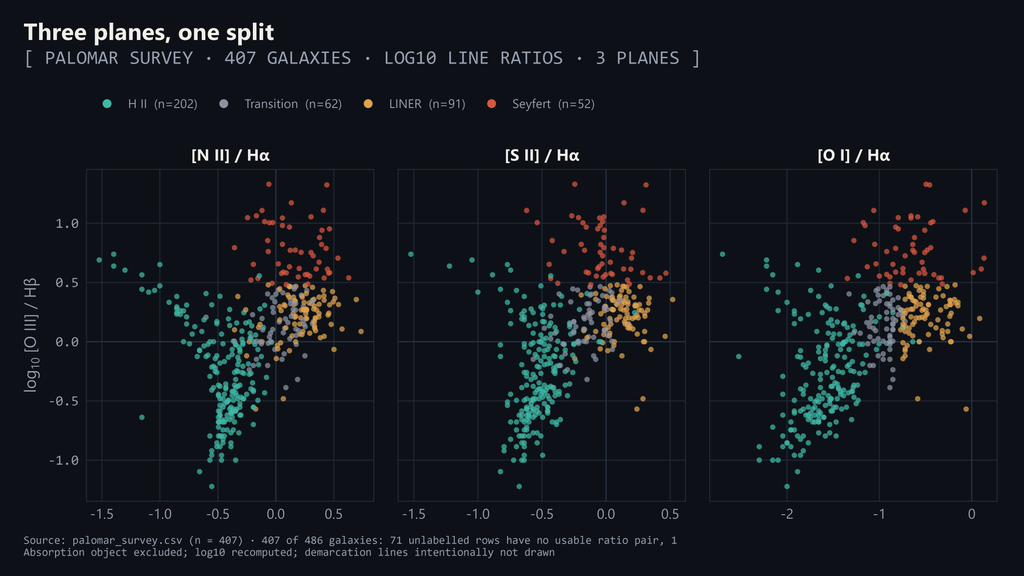

图 1: Three diagnostic planes, one split: star-forming galaxies hold the low-ionization corner, AGN classes the high-ionization corner.

**读数**：左下角全是青色的 H II，右上角是琥珀的 LINER 与珊瑚的 Seyfert——三种比值给出的分离方向一致。轴向本身也说明物理：纵轴越高（[O III]/Hβ 越强）代表电离越硬，横轴越右（低电离谱线相对 Hα 越强）代表激发越偏向 AGN。本报告只陈述图上分布，不引用文献分界线（无可引证系数来源，故不画）。

## 四类到底靠哪个比值分开

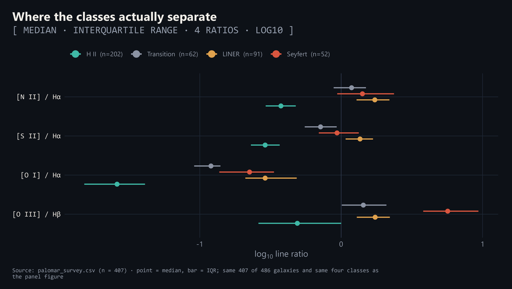

图 2: Class medians and interquartile ranges across four ratios: the Seyfert / LINER split lives in [O III] / H-beta, not in [N II] / H-alpha.

**读数**（中位数 [下四分位, 上四分位]，均为 log10）：

- H II 在四个比值上全部最低：[N II] −0.43 [−0.53, −0.32]、[S II] −0.54 [−0.64, −0.43]、[O I] −1.59 [−1.82, −1.39]、[O III] −0.31 [−0.59, 0.00]。
- Seyfert 的 [O III]/Hβ 最高：0.75 [0.58, 0.97]，比 H II 高 1.06 dex，是四类里唯一上四分位逼近 1 的。
- **Seyfert 与 LINER 的区分不在 [N II]/Hα**：0.15 [−0.03, 0.37] 对 0.24 [0.11, 0.34]，区间大幅重叠；把它们分开的是 [O III]/Hβ（0.75 对 0.24）。
- Transition 在四个比值上都夹在 H II 与 AGN 之间，但 [O I]/Hα（−0.92 [−1.04, −0.85]）比 LINER（−0.54）和 Seyfert（−0.65）都更靠近 H II 一侧。

图 2 的数字基础（各类别在四个比值上的 log10 中位数与四分位，四类共用同一批星系）：

表 1: 图 2 的原始数字：log10 中位数与四分位（n = 407，四类共用同一批星系）

| 类别 | 比值 | 中位数 | 下四分位 | 上四分位 | n |
| --- | --- | --- | --- | --- | --- |
| H II | [O III] / Hβ | -0.31 | -0.59 | +0.00 | 202 |
| Transition | [O III] / Hβ | +0.16 | +0.00 | +0.32 | 62 |
| LINER | [O III] / Hβ | +0.24 | +0.11 | +0.34 | 91 |
| Seyfert | [O III] / Hβ | +0.75 | +0.58 | +0.97 | 52 |
| H II | [O I] / Hα | -1.59 | -1.82 | -1.39 | 202 |
| Transition | [O I] / Hα | -0.92 | -1.04 | -0.85 | 62 |
| LINER | [O I] / Hα | -0.54 | -0.68 | -0.31 | 91 |
| Seyfert | [O I] / Hα | -0.65 | -0.86 | -0.48 | 52 |
| H II | [S II] / Hα | -0.54 | -0.64 | -0.43 | 202 |
| Transition | [S II] / Hα | -0.15 | -0.26 | -0.03 | 62 |
| LINER | [S II] / Hα | +0.13 | +0.03 | +0.23 | 91 |
| Seyfert | [S II] / Hα | -0.03 | -0.16 | +0.12 | 52 |
| H II | [N II] / Hα | -0.43 | -0.53 | -0.32 | 202 |
| Transition | [N II] / Hα | +0.07 | -0.05 | +0.18 | 62 |
| LINER | [N II] / Hα | +0.24 | +0.11 | +0.34 | 91 |
| Seyfert | [N II] / Hα | +0.15 | -0.03 | +0.37 | 52 |

## 方法与口径

| 项 | 值 |
| --- | --- |
| 数据 | 主数据源 `data/palomar_survey.csv`（486 × 20）；`data/palomar_emission_lines.csv`（418 × 8）用于核对四个比值列的量纲 |
| 入图样本 | 407 个星系：带 activity_type 标签、且四个比值全部有值 |
| 剔除 | 71 行无标签（经查全部缺 [N II] 或 [O III] 比值）；1 个 Absorption 天体（n=1） |
| 口径链（原始 → 入图） | raw 486 -> plotted 407 (71 行无 activity_type 且缺 [N II] 或 [O III] 比值; 1 个 Absorption 天体（n=1）)；图例与脚注一律按入图口径 407 报数 |
| 比值口径 | 对 `log_nii_ha` / `log_sii_ha` / `log_oi_ha` / `log_oiii_hb` 四列**自行取 log10**：列名带 log_ 前缀，但列内是线性比值，不是对数值 |
| 不画的东西 | 文献分界线（找不到可引证的系数来源）；未分类不当作类别 |